# Doom Scrolling: A TikTok Data Story

## What is my data about?

Well I was curious about my social media habits and engagement with TikTok so i logged data every time I encountered a TikTok while scrolling 📱. Over multiple weeks, through a google form, I recorded the type of content, number of likes, comments, time spent watching, and how I interacted with it. Lets see how much I need to cut down on TikTok 😔

[figure not shown]

Buzz and Woody from Toy Story with the caption data data everywhere

## When am I scrolling the most?

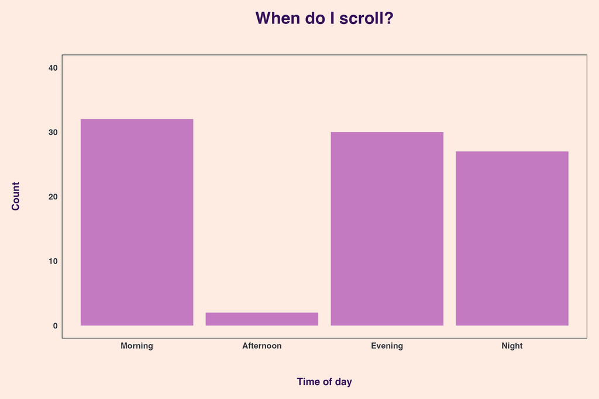

Bar chart showing the number of TikToks observed by time of day, with categories Morning, Afternoon, Evening, and Night on the x-axis and count on the y-axis

Even though I should be getting most of my work done during that time… as a uni student, mornings are for class, and well evenings, just to take a teeny tiny scrolling break 😆

## What content am I actually interacting with?

Whether it’s Code Geass edits, Breaking Bad clips, or JoJos memes - Media/Entertainment really does get my attention.

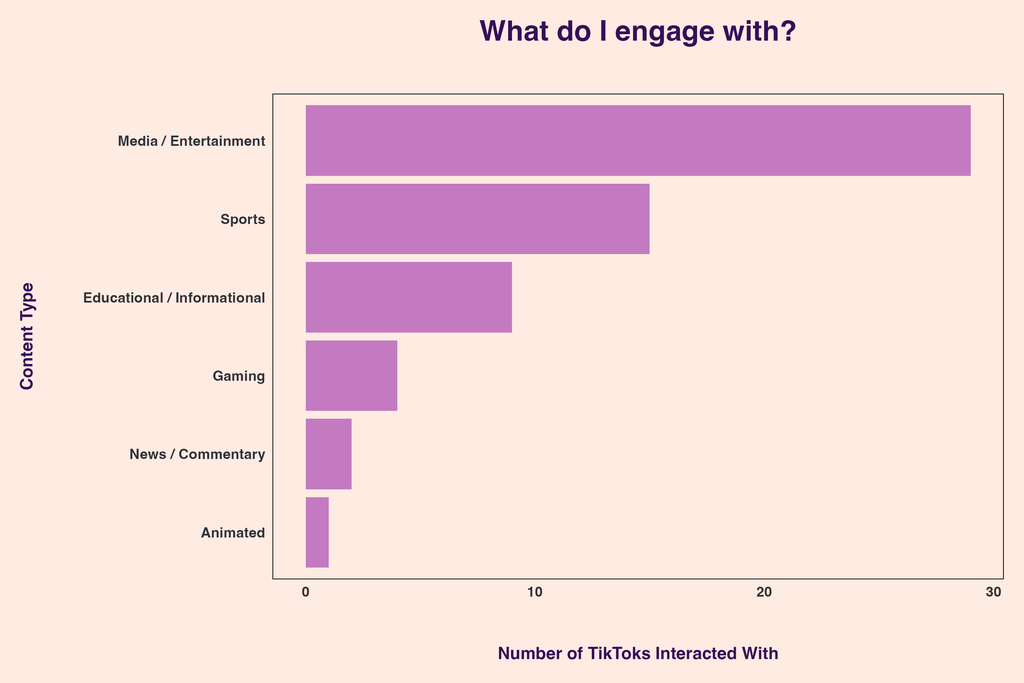

Horizontal bar chart showing the number of TikToks interacted with by content type, ordered from least to most interactions

Other content like News or Gaming barely gets a look in, and unsurprisingly, advertisements/sponsorships are just scrolled past, don’t even make it onto the plot 🤭

## Does popularity predict how long I watch?

You might expect that if a video has millions of likes, I have to watch it, right?

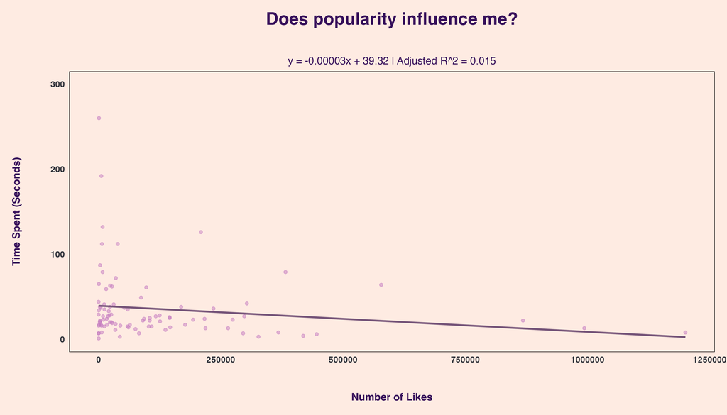

Scatter plot of number of likes on the x-axis and time spent in seconds on the y-axis, with a linear trend line

But the data says otherwise… with the adjusted R^2 of 0.015 (close to zero), likes have almost no relationship with how long I watch TikToks. I guess I’m not a 🐑 after all!

## What did I find out?

I spend way too much time on TikTok, and even more time trying to analyse TikTok

and I think I found a way to stop this addiction ⬇️ ദ്ദി(ᵔᗜᵔ)

[figure not shown]

A gif of a guy punching his laptop